# DSCI 554 Exploratory and Statistical Data Analysis Assignment

# Author: Anastasia Haidar

Description The assignment involves conducting an exploratory data analysis (EDA) on UN Data, focusing on visual analytics. In this task, you will utilize generative AI to create R Markdown and Jupyter notebooks. Document the notebooks to present and effectively communicate the EDA findings to a peer data scientist.

Use the following libraries: Altair: in Jupyter notebook Matplotlib: in Jupyter notebook Seaborn: in Jupyter notebook Pandas: in Jupyter notebook

```python
#Libraries
import pandas as pd
import numpy as np
import matplotlib.pyplot as plt
import seaborn as sns
import altair as alt
from scipy import stats
```

```python
#load precipitation data using pandas
precipitation_data = pd.read_csv('./data/UNdata_Export_20260127_185526138.csv')

#clean data
#remove value footnotes and unit columns
precipitation_data = precipitation_data.drop(columns=['Value Footnotes', 'Unit'])

#change 'Value' column to numeric
precipitation_data['Value'] = pd.to_numeric(precipitation_data['Value'], errors='coerce')

#drop rows with missing values in 'Value' column
precipitation_data = precipitation_data.dropna(subset=['Value'])

#treat zeros as missing since they are suspicious --> R markdown EDA showed that all zero values were from Bolivia,
#likely indicating missing data/incorrect recording rather than actual zero precipitation
precipitation_data.loc[precipitation_data['Value'] == 0, 'Value'] = np.nan

#drop the resulting NaNs
precipitation_data = precipitation_data.dropna(subset=['Value'])

precipitation_data.head()
```

|  | Country or Area | Year | Value |
| --- | --- | --- | --- |
| 0 | Albania | 2017 | 32224.0 |
| 1 | Albania | 2016 | 38810.0 |
| 2 | Albania | 2015 | 32711.0 |
| 3 | Albania | 2014 | 37172.0 |
| 4 | Albania | 2013 | 30615.0 |

Descriptive Stats & Imbalance: Understand country-level imbalance in the data set (as seen in Rmarkdown)

```
              Value
count  2.408000e+03
mean   4.869325e+05
std    1.866559e+06
min    1.000000e-01
25%    3.336475e+03
50%    4.281850e+04
75%    2.212385e+05
max    1.595565e+07
Country or Area
Antigua and Barbuda         32
Armenia                     29
Jordan                      29
Finland                     29
France                      29
                            ..
New Zealand                  1
Republic of Korea            1
Nigeria                      1
Thailand                     1
United States of America     1
Name: count, Length: 138, dtype: int64
```

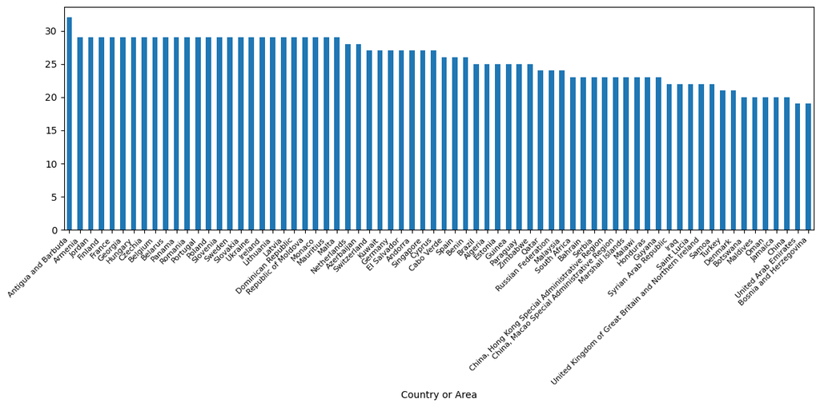

```python
#basic summary using pandas
precip_summary = precipitation_data.describe()
print(precip_summary)

#count number of entries per country
country_counts = precipitation_data['Country or Area'].value_counts()
print(country_counts)

#plot counts visually
count_plot = country_counts.head(70).plot(kind='bar', figsize=(12,6)) #only the first 70 countries for better visualization

count_plot.tick_params(axis='x', labelsize=8)
plt.xticks(rotation=45, ha='right')

plt.tight_layout()
plt.show()
```

It is clear that there is a significant imbalance in the dataset, with some countries having far more entries of precipitation values than other countries. We should keep that in consideration when performing any analysis on this data, especially in country-based analysis.

As part of EDA, we can also see how precipitation changes over time (globally). Precipitation by year can allow us to see potential long-term temporal trends in precipitation.

```
Year
0        98
1990     79
1991     25
1992     25
1993     25
1994     24
1995     76
1996     62
1997     63
1998     62
1999     73
2000     89
2001     90
2002     90
```

[output cut: 20 more lines]

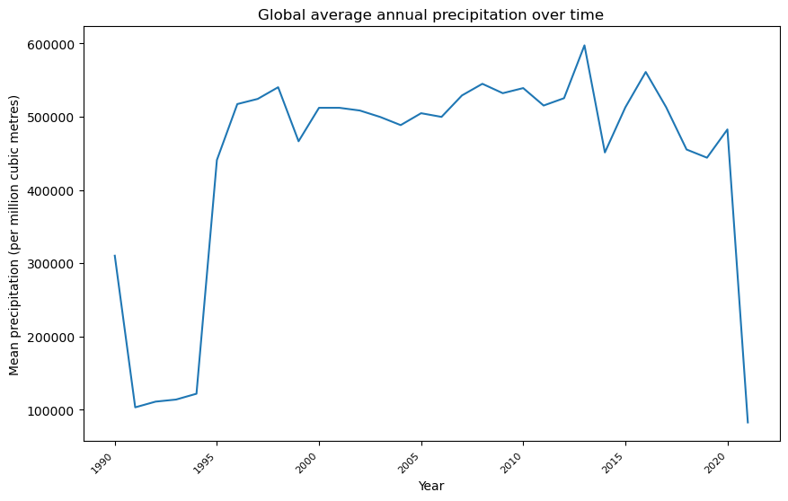

```python
#first let's look at the distribution of years, as we know from the Rmarkdown EDA that some years have far more entries than others.
#many years are labels as zero too

year_counts = precipitation_data['Year'].value_counts().sort_index()
#print(year_counts) --> we see that there are 98 instances of the year '0', which is not a real year
#as in the findings of the EDA in Rmarkdown, where we saw that Bolivia accounts for all the 'zero'
#precipitation values in the dataset - likely due to missing values rather than actual zero precipitation.

#Earlier cleaning did not include 'Year' column cleaning, so doing that now.
#treat year '0' as missing data and remove those rows since we are looking at temporal trends
#convert Year to numeric first
precipitation_data['Year'] = pd.to_numeric(precipitation_data['Year'], errors='coerce')

#treat year '0' as missing
precipitation_data.loc[precipitation_data['Year'] == 0, 'Year'] = pd.NA

#convert to integer year type (no decimals)
precipitation_data['Year'] = precipitation_data['Year'].astype('Int64')

#drop missing years for temporal analysis
precipitation_data = precipitation_data.dropna(subset=['Year'])
print(year_counts)

#plot global average precipitation by year
global_trend = (
    precipitation_data
    .groupby('Year')['Value']
    .mean())

plt.figure(figsize=(10,6))
plt.plot(global_trend.index, global_trend.values)
plt.xticks(rotation=45, ha='right', fontsize=8)
plt.yticks(fontsize=10)
plt.xlabel("Year")
plt.ylabel("Mean precipitation (per million cubic metres)")
plt.title("Global average annual precipitation over time")
plt.show()
```

Here, we see large dips in precipitation around 1991 and 1994, as well as slight dips around 2000 and 2014. These dips may correspond to significant climatic/precipatory events in those years, however, since we do not account for country-level imbalance in this plot, we should be cautious in interpreting these trends. Further, given the counts we see per year for the dataset, these dips and spikes could just be accounted for by the amount of data we have available for those years.

Next, we can examine Year vs Precipitation with a regression using seaborn. We can assess whether there is a systematic temporal trend in precipitation values across countries or not. Given that our previous EDA showed imbalance in the dataset, we should be cautious in interpreting the results of this regression analysis and transform the data accordingly using log transformation.

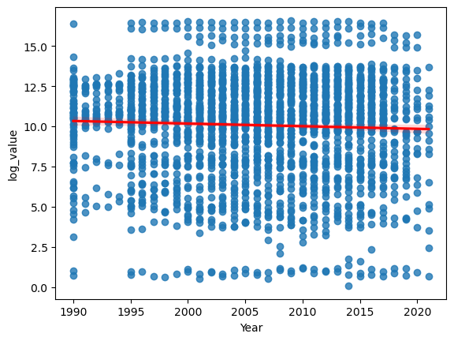

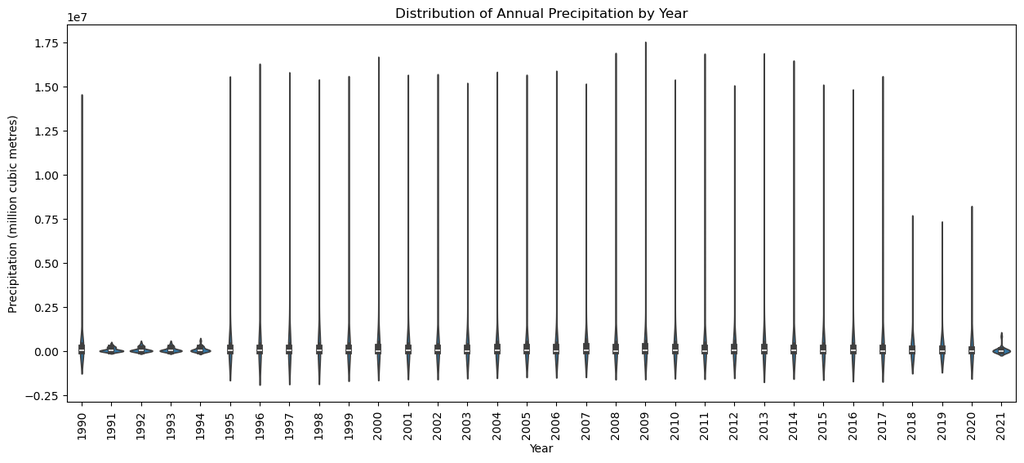

```python
#plot temporal trend: Year vs. Precipitation across all countries
#since the data is so skewed with some years having little or no data
#we can proceed to log-transform the precipitation values to see if that helps visualize any trends

#log transformation
precipitation_data['log_value'] = np.log1p(precipitation_data['Value'])
sns.regplot(
    data=precipitation_data,
    x="Year",
    y="log_value",
    line_kws={"color": "red"}
)

#since the Year data is being treated as categorical, the scatter and regression do not tell us much.
#we can proceed with violin plots to see the distribution of precipitation values across different years.
plt.figure(figsize=(15,6))
sns.violinplot(
    data=precipitation_data,
    x='Year',
    y='Value'
)
plt.xticks(rotation=90)
plt.ylabel("Precipitation (million cubic metres)")
plt.title("Distribution of Annual Precipitation by Year")
plt.show()
```

Given the violin plot output, it would be useful to see if there are significant differences between years in terms of precipitation values. Grouping the years by decade may be best for comparison due to the large number of years in the dataset and the imbalance in data across years. So, we proceed with significant testing using ANOVA to see if there are significant differences in precipitation values across decades.

```
ANOVA F-statistic: 0.71, p-value: 0.5482
```

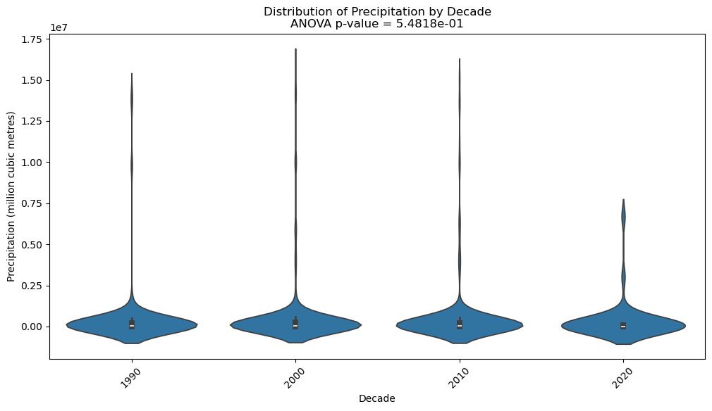

```python
#create decade column
precipitation_data['Decade'] = (precipitation_data['Year'] // 10) * 10

#group precipitation values by decade
decade_groups = [group['Value'].values for name, group in precipitation_data.groupby('Decade')]

#perform one-way ANOVA
f_stat, p_value = stats.f_oneway(*decade_groups)
print(f"ANOVA F-statistic: {f_stat:.2f}, p-value: {p_value:.4f}")

#replot violin plot by decade
plt.figure(figsize=(12,6))
sns.violinplot(data=precipitation_data, x='Decade', y='Value')
plt.xticks(rotation=45)
plt.ylabel("Precipitation (million cubic metres)")
plt.title(f"Distribution of Precipitation by Decade\nANOVA p-value = {p_value:.4e}")
plt.show()
```

As seen above, the resulting p-value for our ANOVA is 0.5482. This indicates that there are no statistically significant differences in precipitation values across decades in our dataset. The variation may be accounted for within decades rather than between decades.

Next, we can try to combine visualization of our three variables using Altair. Altair is an interactive visualization tool, so we can use it to explore all three variables at once: time, precipitation, and country.

```python
#plot precipitation by year and country using Altair
#NOTE: CHART IS INTERACTIVE. ZOOM IN BY SCROLLING DOWN AND OUT BY SCROLLING UP. PAN BY CLICKING AND DRAGGING.
#This is an effective way to zoom in on the very dense areas of the plot which are hard to see otherwise
#(around less than 1,000,000 million cubic metres of precipitation)

alt.Chart(precipitation_data).mark_circle(size=60).encode(
    x='Year:O', #treat year as ordinal
    y='Value:Q',
    color='Country or Area:N',
    tooltip=['Country or Area', 'Year', 'Value']
).properties(
    title="Annual precipitation by country over time"
).interactive()
```

[interactive chart not shown]

The interactive nature of the plot helps with visualizing the dense data points. We can see that most countries have precipitation values clustered below 1,000,000 million cubic metres, with potential outliers above that threshold. This once again may just be due to the imbalance in our data set where both certain countries and certain years have far more data points than others.

Finally, we can take a closer look a potential correlations between precipitation in specific countries and certain decades. We can calculate correlations between countries to give us a country-by-country correlation matrix, showing which countries have similar precipitation patterns over time. Then, we can visualize the correlations as a heatmap. This captures potential multivariate relationships as an association between multiple countries’ precipitation trends.

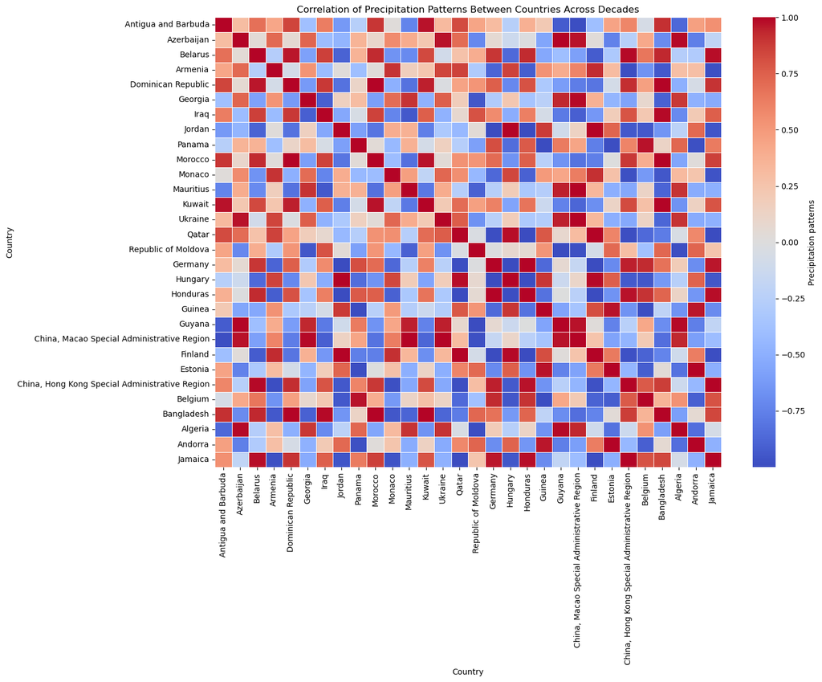

```python
#use the previously created decade column to create a pivot table for the heatmap
#pivot table of mean precipitation per country per decade
heatmap_data = (
    precipitation_data
    .groupby(['Country or Area', 'Decade'])['Value']
    .mean()
    .reset_index()
    .pivot(index='Country or Area', columns='Decade', values='Value'))

#calculate correlations between countries
country_corr = heatmap_data.T.corr()  # correlation across decades

#keep only countries with most data
top_countries = country_corr.count().sort_values(ascending=False).head(30).index
corr_subset = country_corr.loc[top_countries, top_countries]

#plot correlation heatmap
plt.figure(figsize=(15,12))
sns.heatmap(
    corr_subset,
    cmap='coolwarm',
    center=0,
    linewidths=0.5,
    cbar_kws={'label': 'Precipitation patterns'}
)
plt.title("Correlation of Precipitation Patterns Between Countries Across Decades")
plt.xlabel("Country")
plt.ylabel("Country")
plt.tight_layout()
plt.show()
```

This condensed heatmap helps us see some strong postive and negative relationships between the top 30 countries based on data availability. For example, we see strong postive relationships between Germany and Honduras (as well as several other countries), indicating that their precipitation patters over decades are similar. We also see strong negative relationships, such as Qatar and Jamaica or Guinea and Panama, indicating that their precipitation patterns are dissimilar/likely opposite. These relationships may be due to geographic/climatic similarities or differences between countries, however further analysis would be needed to confirm this.